# Course 5:Reproducible Research - Peer Assignment 1

## Number 1: Loading and processing the data

```r
library(dplyr)
library(ggplot2)
```

### Load the data

```r
originalData <- read.csv("~/R/R Course/Course 5/activity.csv")
```

### Remove NAs from the data

```r
activityData <- originalData[complete.cases(originalData), ]
```

## Number 2: What is mean total number of steps taken per day?

### Group data by day

```r
byday <- group_by(activityData, date)

stepsPerDay <- summarize(byday, total = sum(steps, na.rm = TRUE))
```

### Create a histogram showing total number of steps per day

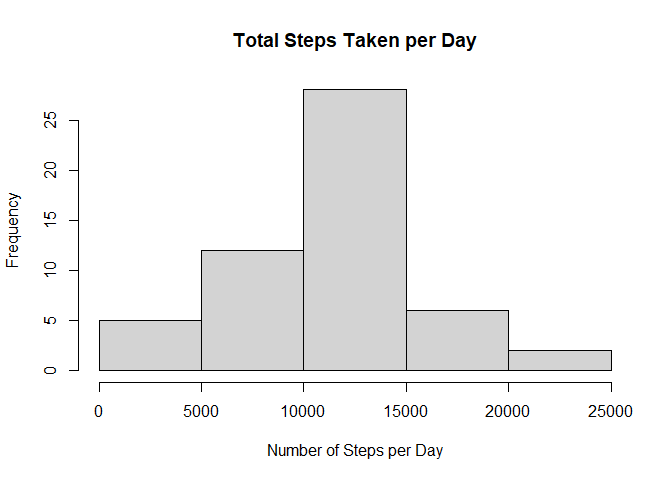

```r
hist(stepsPerDay$total, main = "Total Steps Taken per Day", xlab = "Number of Steps per Day", ylab = "Frequency")
```

### Calculate mean and median of steps per day

```r
mean(stepsPerDay$total)
```

```
## [1] 10766.19
```

```r
median(stepsPerDay$total)
```

```
## [1] 10765
```

### The mean is 10766.19 and the median is 10765.

## Number 3: What is the average daily activity pattern?

### Make a time series plot (i.e. type = “l”) of the 5-minute interval (x-axis) and the average number of steps taken, averaged across all days (y-axis).

#### First, calculate average steps per interval

```r
avgStepsPerInterval <- aggregate(steps ~ interval, activityData, mean)
```

#### Second, plot data as a time series plot

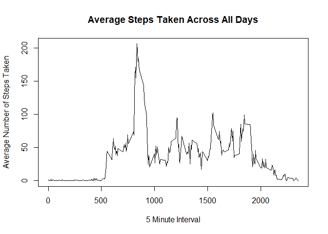

```r
plot(avgStepsPerInterval$interval, avgStepsPerInterval$steps, type = "l", main = "Average Steps Taken Across All Days", xlab = "5 Minute Interval", ylab = "Average Number of Steps Taken")
```

### Find which 5-minute interval, on average across all the days in the dataset, contains the maximum number of steps

#### First, find maximum steps interval index

```r
maximumStepsRow <- which.max(avgStepsPerInterval$steps)
avgStepsPerInterval[maximumStepsRow,]
```

```
##     interval    steps
## 104      835 206.1698
```

#### Second, find values for maximum steps interval index

```r
maximumSteps <- avgStepsPerInterval[maximumStepsRow,1]
print(maximumSteps)
```

```
## [1] 835
```

## Number 3: Imputing missing values

### Calculate and report the total number of missing values in the dataset (i.e. the total number of rows with NAs)

```r
allNAs <- sum(is.na(originalData$steps))
allNAs
```

```
## [1] 2304
```